# Apple shim (iOS/macOS NEPacketTunnelProvider)

# Apple shim (iOS/macOS NEPacketTunnelProvider)

**Revision:** 1 **Last modified:** 2026-06-25T00:00:00Z

> Master technical specification — Volume 4 (Clients), nano-detail deep-dive. This document **deepens** the Apple row of the per-platform shim matrix [03-client §5.1] into an implementation-ready specification of the `apps/access/{ios,macos}` `NEPacketTunnelProvider` (Swift), the Apple impl of the `TunnelPlatform` contract [03-client §4], the Swift⇄Rust `helix-core` staticlib FFI surface, the two-process status bridge, the **iOS Network-Extension memory ceiling** (the program's single hardest constraint, CI4), the size-first `aarch64-apple-ios` build, and macOS desktop-class differences. SPEC-ONLY: it describes **what to build**, not the shipping product. Sources cited inline by id — `[03-client §N]` = `final/03-client-core-and-ui.md`; `[01-TT §N]` = `final/v02-data-plane/transport-trait.md`; `[01-ORCH §N]` = `final/v02-data-plane/orchestrator-and-state.md`; `[04_UI]` = `04_VPN_CLD/HelixVPN-helix-ui-Flutter.md`; `[04_ARCH §N]` = `04_VPN_CLD/HelixVPN-Architecture-Refined.md`; `[04_P0 §N]` = `04_VPN_CLD/HelixVPN-Phase0-Spike.md`; `[research-ios_android]` = `v09-research/research-ios_android.md`; `[research-flutter_ffi]` = the flutter_rust_bridge/UniFFI research digest; `[SYN §N]` = the cross-document synthesis. Any claim not grounded in that evidence base is tagged `UNVERIFIED` per constitution §11.4.6 — never fabricated.
- 0. Position, ownership, and invariants
- 1. The two-process reality (extension vs containing app)
- 2. The Apple `TunnelPlatform` implementation (Dart side)
- 3. `NEPacketTunnelProvider` (Swift) — full lifecycle
- 4. The Swift⇄Rust FFI surface (C ABI / UniFFI)
- 5. The status bridge — core `TunnelStatus` → Dart EventChannel
- 6. The iOS NE memory ceiling — the hard constraint
- 7. Swift⇄Rust staticlib build (`aarch64-apple-ios`)
- 8. macOS desktop-class differences
- 9. Lifecycle state machines
- 10. Error handling & edge cases
- 11. Memory / size / performance budgets
- 12. Test points — tied to the §11.4.169 test-type vocabulary
- 13. Cross-doc seams & surfaced decisions
- Sources verified

## 0. Position, ownership, and invariants

### 0.1 What this document owns

This document owns the **Apple `TunnelPlatform` shim** — the only Apple-specific code in the client stack [03-client §4 O-payoff]. Concretely:

1. The Dart `IosTunnelPlatform` / `MacosTunnelPlatform` impls of the `TunnelPlatform` contract [03-client §4] that marshal `startTunnel`/`stopTunnel`/`events()` onto `NETunnelProviderManager` (§2).
2. The `NEPacketTunnelProvider` subclass (`PacketTunnelProvider.swift`) that owns `packetFlow`, configures `NEPacketTunnelNetworkSettings`, and pumps packets through the in-extension Rust `helix-core` (§3) [03-client §5.1, 04_P0 §6].
3. The **Swift⇄Rust C-ABI FFI surface** the extension links against (the `cbindgen` header over the `helix-ffi` crate; UniFFI is the typed alternative — decision D-CLIENT-3) (§4) [03-client §3, D-CLIENT-3].
4. The **two-process status bridge** that carries the core's `TunnelStatus` stream (emitted *inside the extension process*) back to the Flutter UI (running in the *containing app process*) as `PlatformTunnelEvent`s (§5) [01-ORCH §4].
5. The **iOS NE memory-ceiling discipline** (G3 make-or-break) — measurement, budgets, and the documented fallback ladder (§6) [04_P0 §6.4, research-ios_android §1].
6. The **size-first `aarch64-apple-ios` staticlib build** of `helix-core` (§7) [research-ios_android §2].

### 0.2 What this document does NOT own

- The `helix-core` internals (WG crypto, `helix-transport` carriers, the orchestrator three-loop, the ladder) — owned by Volume 2 [01-TT, 01-ORCH]; this doc links the staticlib and drives its *exported* surface only [03-client §0].
- The shared Flutter UI (`ConnectButton`, `ExitPicker`, `helix_design`, Riverpod) — it is byte-identical across all platforms and ports for free; the shim does not [03-client §5 payoff, §7, §8].
- The FFI *surface contract* itself (`start/stop/status_stream/attach_tun/…` + the mirrored `TunnelStatus`) — fixed by [03-client §3]; this doc owns only the *Apple binding* of that surface (the cbindgen/UniFFI header + the in-extension call sites).
- The `TransportConfig` source (`WatchNetworkMap`) — doc 02; the shim hands the core a resolved session/map token and never invents an endpoint (I3) [01-TT §3.1].

### 0.3 Invariants this document inherits and tightens

[output not shown]

## 1. The two-process reality (extension vs containing app)

The single fact that shapes every Apple decision: **on Apple a Packet Tunnel Provider is a separate process from the app that hosts the UI** [research-ios_android §1.4, 04_P0 §6]. The Flutter UI runs in the *containing app* (`Helix Access.app`); the `NEPacketTunnelProvider` runs in a *system-spawned extension process* (`HelixTunnel.appex`) with its **own address space and its own jetsam memory budget**. `helix-core` runs **inside the extension**, because that is where `packetFlow` (the packet I/O) lives. Therefore the core's `TunnelStatus` stream is generated in the extension and must cross a process boundary to reach the UI.

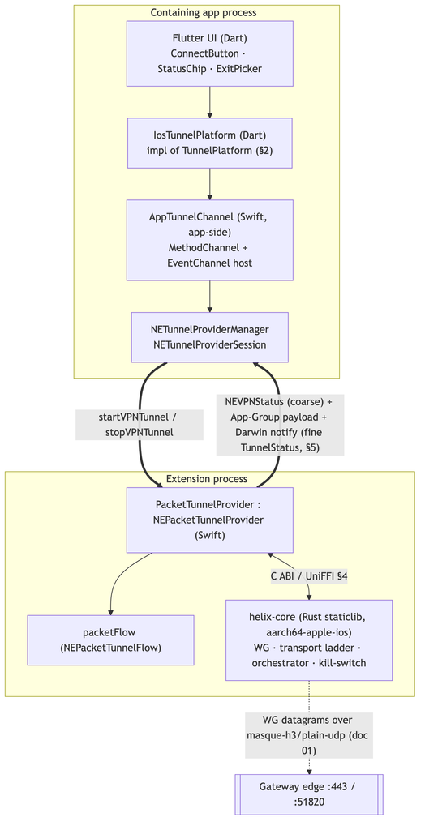

> **Why this matters (CI2).** The app cannot read the core's in-process broadcast channel directly. It must (a) observe `NEVPNStatusDidChange` for coarse transitions (`connecting/connected/reconnecting/disconnected`), and (b) receive the *fine* status (`Handshaking` vs `Connecting`, `Connected{transport,rtt}`, `Down{reason}`) via the cross-process push of §5. Painting the UI on `NEVPNStatus` alone would lose the transport/rtt/reason detail the `StatusChip` needs and would risk the "connected but actually handshaking" lie CI2 forbids.

## 2. The Apple `TunnelPlatform` implementation (Dart side)

The Apple shim satisfies the shared `TunnelPlatform` contract [03-client §4]:

```
abstract class TunnelPlatform {
  Future<void> startTunnel(TunnelConfig cfg);
  Future<void> stopTunnel();
  Stream<PlatformTunnelEvent> events();
}
```

### 2.1 `IosTunnelPlatform` (Dart) — the marshaller

```
// helix_core_ffi/lib/src/platform/ios_tunnel_platform.dart
class IosTunnelPlatform implements TunnelPlatform {
  static const _method = MethodChannel('helixvpn/tunnel');
  static const _events = EventChannel('helixvpn/tunnel/events');

  @override
  Future<void> startTunnel(TunnelConfig cfg) async {
    // App-side ONLY configures + starts NETunnelProviderManager; it does NOT touch packets.
    await _method.invokeMethod('startTunnel', <String, dynamic>{
      'overlayIp':   cfg.overlayIp,             // 100.64.0.7/32 or fd7a:…/128
      'routes':      cfg.routes,                // AllowedIPs → includedRoutes
      'dnsServers':  cfg.dnsServers,            // tunnel DNS (anti-leak)
      'mtu':         cfg.mtu,                   // 1280 MASQUE / 1420 plain WG [01-TT §4.8]
      'sessionToken':cfg.sessionOrMapToken,     // → helix_core_start, never logged (§11.4.10)
      // NOTE: splitExcludeApps is NOT honoured on iOS (no per-app VPN for 3rd-party apps,
      //       §10 E7); macOS supports excludeLocalNetworks only. Surfaced, not silently dropped.
    });
  }

  @override
  Future<void> stopTunnel() => _method.invokeMethod('stopTunnel');

  @override
  Stream<PlatformTunnelEvent> events() =>
      _events.receiveBroadcastStream().map(_decodeEvent); // §5.6
}
```

### 2.2 Channel verbs (Dart → app-side Swift)

| Verb | Direction | Swift handler | Effect |
| --- | --- | --- | --- |
| `startTunnel(args)` | Dart → app Swift | `AppTunnelChannel.start` | load/save `NETunnelProviderManager`, `startVPNTunnel(options: {token,…})` |
| `stopTunnel()` | Dart → app Swift | `AppTunnelChannel.stop` | `session.stopVPNTunnel()` |
| `events()` stream | app Swift → Dart | `EventChannel.EventSink` | emits `up/down/permissionDenied/revoked/error` decoded from §5 |

`startTunnel`/`stopTunnel` complete on the app-side `MethodChannel`; they do **not** carry status — status flows out-of-band on the EventChannel fed by the §5 bridge so the contract's "`events()` is lifecycle only, never data" rule [03-client §4 O3] holds.

### 2.3 Permission-aware start (O1)

```
// apps/access/ios/Runner/AppTunnelChannel.swift  (app process)
func start(_ args: [String: Any], result: @escaping FlutterResult) {
  NETunnelProviderManager.loadAllFromPreferences { managers, err in
    if let err { return result(self.flError("load", err)) }          // O1: surface, no half-open
    let mgr = managers?.first ?? NETunnelProviderManager()
    let proto = NETunnelProviderProtocol()
    proto.providerBundleIdentifier = "io.helixvpn.access.tunnel"      // the .appex bundle id
    proto.serverAddress = (args["overlayIp"] as? String) ?? "HelixVPN"
    // Non-secret config travels in providerConfiguration; the SESSION TOKEN travels in
    // startVPNTunnel(options:) (kept out of the saved preferences plist → §11.4.10):
    proto.providerConfiguration = ["routes": args["routes"]!, "dns": args["dnsServers"]!,
                                   "mtu": args["mtu"]!]
    mgr.protocolConfiguration = proto
    mgr.localizedDescription  = "HelixVPN"
    mgr.isEnabled = true
    mgr.saveToPreferences { saveErr in
      if let saveErr = saveErr as NSError? {
        // Permission sheet declined → NEVPNError.configurationReadWriteFailed / .Code(1)
        if saveErr.domain == NEVPNErrorDomain { return result(self.flPermissionDenied()) } // O1
        return result(self.flError("save", saveErr))
      }
      mgr.loadFromPreferences { _ in
        do {
          let opts: [String: NSObject] = [
            "sessionToken": (args["sessionToken"] as! String) as NSObject  // ephemeral, not persisted
          ]
          try (mgr.connection as! NETunnelProviderSession).startVPNTunnel(options: opts)
          result(nil)                                                   // start accepted (NOT "connected")
        } catch { result(self.flError("startVPNTunnel", error)) }
      }
    }
  }
}
```

> **O1 honesty (§11.4.6).** A declined VPN-permission sheet MUST surface as `PlatformTunnelEventKind.permissionDenied`, never `error`, and leave **no** saved-enabled manager behind (the next `loadAllFromPreferences` must not find a dangling config). The session token rides in `startVPNTunnel(options:)` and is therefore **never written to the preferences plist** (§11.4.10 no-secret-at-rest).

## 3. `NEPacketTunnelProvider` (Swift) — full lifecycle

The make-or-break class [04_P0 §6]. It runs in the extension process, owns `packetFlow`, configures the tunnel network settings, links the Rust staticlib, and pumps packets.

### 3.1 Class skeleton

```
// apps/access/ios/HelixTunnel/PacketTunnelProvider.swift   (extension process)
import NetworkExtension
import os

final class PacketTunnelProvider: NEPacketTunnelProvider {
  private let log = Logger(subsystem: "io.helixvpn.tunnel", category: "provider")
  private var started = false                    // idempotency guard (O1)

  override func startTunnel(options: [String: NSObject]?,
                            completionHandler: @escaping (Error?) -> Void) {
    guard !started else { return completionHandler(nil) }   // idempotent (O1)
    started = true
    let cfg = decodeTunnelConfig(options, protocolConfig: self.protocolConfiguration)
    applyNetworkSettings(cfg) { [weak self] err in
      guard let self else { return }
      if let err { self.started = false; return completionHandler(err) }  // no half-open (O1/O4)
      // 1. Wire the core's outbound writer (core → packetFlow → OS) BEFORE start, so no race:
      installTunWriter()                                                  // §3.3
      installStatusCallback()                                             // §5.2
      // 2. Start the Rust core in-process (it owns WG + transport ladder + kill-switch):
      var c = HelixClientConfig(
        sessionToken: cfg.sessionToken,                                   // ephemeral, never logged
        mode: HELIX_MODE_CLIENT,
        mtu: cfg.mtu)
      let rc = helix_core_start(&c)                                       // §4.1
      guard rc == HELIX_OK else {
        self.started = false
        return completionHandler(self.mapCoreError(rc))                   // §10 error map
      }
      // 3. Begin the read pump (packetFlow → core), recursively:
      self.pumpOutbound()                                                 // §3.3
      // 4. Return SUCCESS once the carrier+settings are ready. The fine status
      //    (Handshaking→Connected) is pushed via the §5 bridge, NOT here (CI2).
      completionHandler(nil)
    }
  }

  override func stopTunnel(with reason: NEProviderStopReason,
                           completionHandler: @escaping () -> Void) {
    log.notice("stopTunnel reason=\(reason.rawValue)")
    helix_core_stop()                                                     // §4.1 (O4 quiescent)
    started = false
    // Map the OS stop reason into a Down{reason} for the bridge (§5.5):
    publishStatus(downReasonFor(reason))                                  // best-effort final push
    completionHandler()
  }

  // App→extension request/response (e.g. "getStatus") — the §5 pull path:
  override func handleAppMessage(_ data: Data,
                                 completionHandler: ((Data?) -> Void)?) {
    completionHandler?(currentStatusPayload())                           // §5.3
  }

  // OS is about to suspend the device; flush nothing durable (I5), keep tunnel:
  override func sleep(completionHandler: @escaping () -> Void) { completionHandler() }
  override func wake() { /* WG roams on the new path automatically [01-ORCH §7.5] */ }
}
```

### 3.2 Network settings (the anti-leak configuration)

```
private func applyNetworkSettings(_ cfg: TunnelConfig,
                                  _ done: @escaping (Error?) -> Void) {
  let settings = NEPacketTunnelNetworkSettings(tunnelRemoteAddress: cfg.gatewayHost)
  // overlay IPv4:
  let v4 = NEIPv4Settings(addresses: [cfg.overlayIp], subnetMasks: ["255.255.255.255"])
  v4.includedRoutes = cfg.routes.map { NEIPv4Route(destinationAddress: $0.addr,
                                                   subnetMask: $0.mask) }   // AllowedIPs
  settings.ipv4Settings = v4
  // overlay IPv6 (ULA /48 per tenant, D4 [SYN §3]) when present:
  if let v6 = cfg.overlayIp6 {
    let s6 = NEIPv6Settings(addresses: [v6], networkPrefixLengths: [128])
    s6.includedRoutes = cfg.routes6.map { NEIPv6Route(destinationAddress: $0.addr,
                                                     networkPrefixLength: $0.prefix) }
    settings.ipv6Settings = s6
  }
  // tunnel DNS — the anti-leak core: all :53 goes into the tunnel:
  let dns = NEDNSSettings(servers: cfg.dnsServers)
  dns.matchDomains = [""]                       // match ALL domains → no plaintext :53 off-tunnel
  settings.dnsSettings = dns
  settings.mtu = NSNumber(value: cfg.mtu)        // 1280 MASQUE / 1420 plain WG [01-TT §4.8]
  setTunnelNetworkSettings(settings, completionHandler: done)
}
```

> **DNS-leak note (CI-aligned).** `matchDomains = [""]` forces *every* DNS query through the tunnel DNS — the iOS-NE realization of the orchestrator's "force tunnel DNS; block plaintext :53 off-tunnel" rule [01-ORCH §8.3]. iOS NE has **no userspace firewall**, so the kill-switch is realized by (a) `includeAllNetworks` / `excludeLocalNetworks` on the protocol (§3.4), and (b) the default-route capture above — not by `nft` rules as on Linux.

### 3.3 The packet pump (the O2 seam — no TUN fd on Apple)

Apple gives the extension `packetFlow: NEPacketTunnelFlow` with `readPackets`/`writePackets` — there is **no file descriptor** to hand to the core, so the Android/Linux `attach_tun(fd)` path does **not** apply here [research-ios_android §3 contrast, 03-client §5.1]. Instead the shim pumps packets across the FFI by value:

```
// Outbound: OS app traffic → packetFlow → core (encrypt+send over transport)
private func pumpOutbound() {
  packetFlow.readPackets { [weak self] packets, protocols in
    guard let self else { return }
    for (i, pkt) in packets.enumerated() {
      let isV6 = protocols[i].int32Value == AF_INET6
      pkt.withUnsafeBytes { raw in
        helix_core_tun_out(raw.bindMemory(to: UInt8.self).baseAddress,
                           UInt(pkt.count), isV6)                    // §4.2 — opaque copy (I1)
      }
    }
    self.pumpOutbound()                                              // recurse (NE idiom)
  }
}

// Inbound: core (decrypted IP packets) → packetFlow → OS. Registered ONCE at start:
private func installTunWriter() {
  // The C callback trampolines back into Swift; `ctx` carries `self` (Unmanaged).
  let ctx = Unmanaged.passUnretained(self).toOpaque()
  helix_core_set_tun_writer({ pkt, len, isV6, ctx in
    let me = Unmanaged<PacketTunnelProvider>.fromOpaque(ctx!).takeUnretainedValue()
    let data = Data(bytes: pkt!, count: Int(len))
    let proto = isV6 ? NSNumber(value: AF_INET6) : NSNumber(value: AF_INET)
    me.packetFlow.writePackets([data], withProtocols: [proto])      // §4.2
  }, ctx)
}
```

> **O2/I1 discipline.** The shim copies packet bytes opaquely (`Data(bytes:count:)`) and never parses, logs, or mutates them. All crypto + obfuscation lives in `helix-core` (one core, no fork) [03-client §4 O2, 01-TT §1 I1]. The recursive `readPackets` continuation is the canonical NE pump idiom; it is cancel-safe (a `stopTunnel` tears the provider down and the continuation simply stops being called).

### 3.4 Kill-switch posture on Apple (O4)

iOS/macOS NE realize the "no leaks if the tunnel drops" guarantee [04_ARCH §5.6] through the **protocol configuration**, set on the app side at save time, not by in-extension firewall rules:

| Knob | Effect | Helix mapping |
| --- | --- | --- |
| `NETunnelProviderProtocol.includeAllNetworks` | route ALL traffic into the tunnel; on drop, traffic is blocked | the iOS kill-switch ON state (Strict mode [01-ORCH §8.2]) |
| `.excludeLocalNetworks` | permit RFC1918 LAN (printers) even when `includeAllNetworks` | `KillSwitchConfig.allow_lan` [01-ORCH §8.2] |
| `.enforceRoutes` | OS enforces `includedRoutes` even when other VPNs/configs exist | hardens AllowedIPs capture |
| on-demand rules (`NEOnDemandRule`) | auto-reconnect / always-on | the "always-on VPN" UX (Phase 2) |

The core's internal kill-switch state machine [01-ORCH §8] still drives *when* the tunnel should be up; on Apple the *enforcement* is the OS routing + `includeAllNetworks`, so the in-extension core does NOT install `nft`-equivalent rules (none exist in the NE sandbox). `UNVERIFIED`: whether `includeAllNetworks` fully blocks egress during the extension-restart window on every iOS version — measured in the G3/SC soak (§12), never assumed (§11.4.6).

## 4. The Swift⇄Rust FFI surface (C ABI / UniFFI)

The extension links `helix-core` as a **staticlib** (`crate-type = ["staticlib"]`) and calls its exported C surface generated from the `helix-ffi` crate [03-client §3, research-ios_android §2.4]. Decision **D-CLIENT-3**: UniFFI for typed Swift, cbindgen as the fallback for the raw-callback pump where UniFFI's async/callback ergonomics are thin [03-client D-CLIENT-3]. This section pins the **cbindgen C ABI** (the lowest common denominator both binding generators agree on); the UniFFI typed wrapper is a thin overlay.

### 4.1 Lifecycle + config (C ABI)

```c
// helix_core.h  — cbindgen-generated from helix-ffi/src/ffi_capi.rs
#include <stdint.h>

typedef enum {                       // mirrors api.rs CoreMode [03-client §3.1]
  HELIX_MODE_CLIENT    = 0,
  HELIX_MODE_CONNECTOR = 1,
} HelixCoreMode;

typedef enum {                       // start/stop result; maps to NEVPNError + Down.reason (§10)
  HELIX_OK            = 0,
  HELIX_ERR_CONFIG    = 1,           // bad token / unparseable map      → "host-fatal"
  HELIX_ERR_HANDSHAKE = 2,           // carrier dialled, WG never replied → retry/escalate
  HELIX_ERR_HOST      = 3,           // settings/packetFlow unusable      → "host-fatal"
  HELIX_ERR_AUTH      = 4,           // WG handshake rejected (revoked)   → "auth-failed", NO retry
} HelixResult;

typedef struct {
  const char* session_token;         // ephemeral; NEVER persisted or logged (§11.4.10)
  HelixCoreMode mode;
  uint16_t      mtu;                 // inner WG MTU ceiling [01-TT §4.8]
} HelixClientConfig;

// Start the in-extension core. Returns once WG+transport tasks are spawned (NOT once
// the tunnel is "connected" — that is reported via the status callback, CI2).
HelixResult helix_core_start(const HelixClientConfig* cfg);

// Idempotent graceful stop: FIN the carrier, revert state, stop loops (O4).
void        helix_core_stop(void);

// Apply a fresh resolved map (Phase 1 WatchNetworkMap delta; Phase 0 static map).
HelixResult helix_core_apply_map(const uint8_t* map_cbor, uintptr_t len);
```

### 4.2 The packet pump (C ABI — the Apple-specific seam)

```c
// Outbound: hand ONE plaintext IP packet from packetFlow to the core (it encrypts+sends).
// `is_v6` selects the AF for the inner WG router. Bytes are copied in-crate; the caller's
// buffer is NOT retained past the call (no aliasing of packetFlow storage).
void helix_core_tun_out(const uint8_t* pkt, uintptr_t len, bool is_v6);

// Inbound writer: the core invokes this callback with a DECRYPTED IP packet to write to
// packetFlow. Registered ONCE before start. `ctx` is an opaque app pointer (Unmanaged self).
typedef void (*HelixTunWriter)(const uint8_t* pkt, uintptr_t len, bool is_v6, void* ctx);
void helix_core_set_tun_writer(HelixTunWriter cb, void* ctx);
```

> **Why a callback pump and not `attach_tun(fd)`.** `NEPacketTunnelFlow` exposes `readPackets`/`writePackets`, never a kernel fd, so the [03-client §3] `attach_tun(fd:i32)` entry point is unused on Apple. Android/Linux DO use `attach_tun(fd)` (the `ParcelFileDescriptor`/`tun` fd) [research-ios_android §3]. The FFI crate exports **both** entry points; each platform shim wires the one its OS provides — the core's internal `tun → wg` loop A and `wg → tun` loop B [01-ORCH §3] read/write through whichever sink was installed. This is the only place the otherwise-uniform FFI surface diverges per OS.

### 4.3 Status callback (C ABI — feeds the §5 bridge)

```c
// The core pushes EVERY TunnelStatus transition here (in-extension). Payload is a compact
// CBOR/JSON encoding of the 5-variant TunnelStatus enum (§5.1). Called from the core's
// state-driver task; the Swift handler must be cheap + non-blocking (§5.2).
typedef void (*HelixStatusCb)(const uint8_t* status_cbor, uintptr_t len, void* ctx);
void helix_core_set_status_cb(HelixStatusCb cb, void* ctx);

// Pull the latest status synchronously (for handleAppMessage "getStatus", §5.3).
// Writes up to `cap` bytes into `out`, returns the written length (0 if none yet).
uintptr_t   helix_core_current_status(uint8_t* out, uintptr_t cap);
```

### 4.4 FFI safety & memory rules (release-blocking)

| # | Rule | Why |
| --- | --- | --- |
| F1 | Every `*const u8`/`*mut u8` is **copied in-crate** on entry; no Rust struct ever aliases a Swift-owned buffer past the call. | avoids use-after-free across the FFI; required for `panic=abort` safety (§7). |
| F2 | The status/writer callbacks are `extern "C"` `fn` pointers with a `void* ctx`; the core stores them behind an `AtomicPtr` set once before `helix_core_start`. | no captured-closure ABI mismatch; callback set is happens-before the loops. |
| F3 | A Rust `panic` inside the core MUST NOT unwind across the C ABI — `panic = "abort"` (§7) makes any panic a clean process abort (the extension is restarted by NE) rather than UB. | `panic=abort` is both a size win AND an FFI-soundness requirement. |
| F4 | The session token (`*const c_char`) is copied into a `SecretBytes`-class buffer [01-TT §3.2] and zeroized on drop; it is never logged on either side (§11.4.10). | no-secret-leak. |
| F5 | All FFI functions are `#[no_mangle] pub extern "C"`; the header is **drift-checked** in CI against the crate (a divergence FAILs the build, mirroring the frb contract test [03-client §12]). | one source of truth, no silent surface drift. |

## 5. The status bridge — core `TunnelStatus` → Dart EventChannel

The core's status stream lives **inside the extension**; the UI lives **in the app**. This section pins how a `TunnelStatus` transition becomes a Dart `PlatformTunnelEvent`. **The core-emitted enum is the 5-variant `TunnelStatus` from [01-ORCH §4.1]** — this doc keeps the FFI status payload byte-consistent with that enum; the richer Dart-facing `TunnelStatus` (adding `Disconnected`/`path`/`Danger`) [03-client §3.1] is a *UI projection* layered in `helix_core.dart`, not a second wire enum.

### 5.1 The canonical core-emitted enum (consistency anchor)

```rust
// helix-core/src/status.rs — the SINGLE wire enum the FFI status callback serializes.
// IDENTICAL to [01-ORCH §4.1]; the Apple bridge MUST NOT invent variants.
#[derive(Clone, Debug, PartialEq, Eq)]
pub enum TunnelStatus {
    Connecting,                                    // dialling a rung (carrier handshake)
    Handshaking,                                   // carrier up; WG Noise IK in flight
    Connected { transport: String, rtt_ms: u32 },  // ("masque-h3", 23)
    Reconnecting,                                  // a working tunnel dropped; re-dialling
    Down { reason: String },                       // terminal for this attempt (§5.5 prefixes)
}
```

`Down.reason` uses the [01-ORCH §4.4] stable prefixes (`"stopped" | "pinned-transport-failed" | "ladder-exhausted" | "auth-failed" | "no-route" | "host-fatal"`) so the bridge can classify without parsing prose (§11.4.6 no-guessing).

### 5.2 Push path (extension → app): App-Group file + Darwin notify

The extension cannot call into the app process directly. The recommended **push** mechanism (`UNVERIFIED` exact API names verified on device, but all are standard NE-IPC primitives):

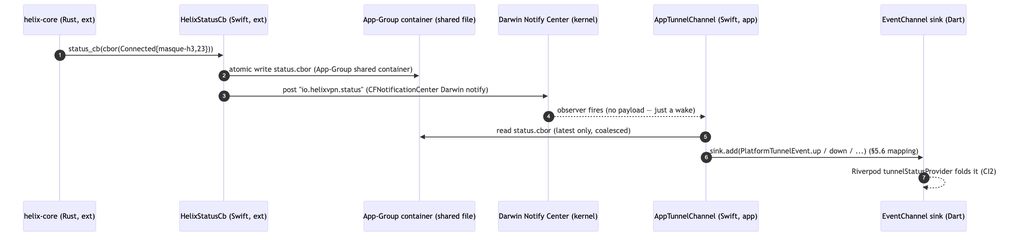

- The status callback writes the latest `TunnelStatus` (CBOR) **atomically** (write-temp + rename) into the App-Group container both processes share, then posts a **Darwin notification** (`CFNotificationCenterGetDarwinNotifyCenter`) — a payload-less cross-process wake. The app's observer reads the *latest* file (coalesced; only the newest state matters, matching the broadcast "skip-to-latest" semantics [01-ORCH §4.2/§4.6]).
- The status callback is **cheap**: serialize + one atomic write + one notify post; it never blocks the core's state-driver task (§4.3 contract).
- **Why not `sendProviderMessage` for push?** `NETunnelProviderSession.sendProviderMessage` is **app→extension request/response only**; the extension cannot originate it. Hence the App-Group-file + Darwin-notify push for extension→app, and `sendProviderMessage` for the *pull* path (§5.3).

### 5.3 Pull path (app → extension): `sendProviderMessage`

On app foreground / cold start / after a Darwin-notify miss, the app pulls the current status to resync (defends against a dropped notification):

```
// app process
func refreshStatus() {
  guard let session = mgr.connection as? NETunnelProviderSession else { return }
  try? session.sendProviderMessage("getStatus".data(using: .utf8)!) { reply in
    if let reply { self.emit(decodeTunnelStatus(reply)) }   // → EventChannel (§5.6)
  }
}
```

The extension answers in `handleAppMessage` (§3.1) via `helix_core_current_status` (§4.3).

### 5.4 Coarse `NEVPNStatus` as a backstop only

`NEVPNStatusDidChange` (`.connecting/.connected/.reconnecting/.disconnecting/.disconnected/ .invalid`) is observed by the app as a **backstop** — it guarantees the app learns of OS-side transitions (e.g. the OS tearing the tunnel) even if a Darwin notify is missed. But it is **coarse** (no transport/rtt/reason), so the fine `TunnelStatus` from §5.2/§5.3 is always the source of truth for the `StatusChip`; `NEVPNStatus` only triggers a §5.3 pull (CI2).

### 5.5 `NEProviderStopReason` → `Down{reason}` mapping (O3)

```
func downReasonFor(_ r: NEProviderStopReason) -> String {
  switch r {
  case .userInitiated:           return "stopped"            // user toggled off (§8.6 only open path)
  case .providerFailed,
       .internalError:           return "host-fatal"
  case .authenticationCanceled,
       .configurationFailed:     return "auth-failed"        // → revoked (O3)
  case .noNetworkAvailable,
       .unrecoverableNetworkChange: return "ladder-exhausted"
  case .providerDisabled,
       .configurationDisabled,
       .configurationRemoved,
       .superceded:              return "auth-failed"        // admin/OS revoked the config (O3)
  @unknown default:              return "host-fatal"
  }
}
```

`device.revoked` propagated from the control plane (doc 02) reaches the core as a map delta whose `peers_removed` includes the active peer → the core emits `Down{reason:"auth-failed"}` [01-ORCH §6.4] → the bridge maps it to `PlatformTunnelEventKind.revoked` (§5.6).

### 5.6 `TunnelStatus` → `PlatformTunnelEvent` decode (Dart)

```
PlatformTunnelEvent _decodeEvent(dynamic raw) {
  final s = TunnelStatus.fromCbor(raw as Uint8List); // mirrors the §5.1 enum
  return switch (s) {
    Connecting()  || Handshaking() || Reconnecting() => PlatformTunnelEvent(PlatformTunnelEventKind.up),  // "in motion"; UI shows amber via the richer projection
    Connected()                                      => PlatformTunnelEvent(PlatformTunnelEventKind.up),
    Down(:final reason) when reason == 'auth-failed' => PlatformTunnelEvent(PlatformTunnelEventKind.revoked, reason),
    Down(:final reason) when reason == 'stopped'     => PlatformTunnelEvent(PlatformTunnelEventKind.down, reason),
    Down(:final reason)                              => PlatformTunnelEvent(PlatformTunnelEventKind.error,  reason),
  };
}
```

> **Boundary note.** `PlatformTunnelEvent` (lifecycle: up/down/permissionDenied/revoked/error) [03-client §4] is intentionally coarser than `TunnelStatus`. The *rich* status (`Connected{transport,rtt}`, `Handshaking`, `Danger`) reaches the UI **directly** via `tunnelStatusProvider` folding the core's `statusStream()` projection [03-client §8.2] — on Apple that stream is fed by the same App-Group/Darwin bridge. `events()` carries only the lifecycle transitions the `TunnelPlatform` contract owns; the two are complementary, not redundant.

## 6. The iOS NE memory ceiling — the hard constraint

CI4: this is the single strongest architectural driver and the reason the core is Rust, not Go [04_ARCH §5.6, SYN §5]. The facts (every figure cited; never hardcoded — §11.4.6):

### 6.1 The facts (research-ios_android §1)

| Fact | Value | Source / status |
| --- | --- | --- |
| Documented Packet-Tunnel-Provider limit (iOS 15–18) | **50 MiB** | Apple DTS (Quinn), measured iOS 16, reconfirmed 17/18 [research-ios_android §1] |
| Historical limit (iOS 11–14, 64-bit) | 15 MiB | [research-ios_android §1] |
| Observed real-world jetsam kill on iOS 17.3.1 | **~15 MB** (despite 50 MiB docs) | reported, root cause `PENDING_FORENSICS` [research-ios_android §1] |
| Dominant kill cause | **transient spikes** during upload-heavy throughput (buffer-pool/QUIC) | sing-box/WireGuard jetsam during speedtest [research-ios_android §1] |
| Scope | the **whole extension process** — Swift + Rust staticlib + every linked lib | [research-ios_android §1.4] |
| Official guidance | **"do not hard code knowledge of these limits"; measure on device** | Quinn, verbatim [research-ios_android §1.2] |

### 6.2 The design rule (engineering conclusion)

Concrete budget-keeping rules the Rust core MUST honour (the in-extension build):

| # | Rule | Realization |
| --- | --- | --- |
| M1 | **Bound every buffer pool.** No per-flow state growth. | fixed-size receive buffer = negotiated MTU + headroom (not an arbitrary large value) [research-ios_android §1.6]; pre-allocated send scratch reused per loop [01-ORCH §3.1]. |
| M2 | **Cap QUIC flow-control windows** in the iOS build. | `masque-h3` carrier built with reduced `quinn` `receive_window`/`stream_receive_window` (iOS profile) — the §6.4 fallback rung 1. |
| M3 | **No backtrace/unwind machinery.** | `panic = "abort"` + `build-std` `panic_immediate_abort` (§7) drops `gimli`/format code [research-ios_android §2]. |
| M4 | **Single fixed receive buffer**, sized to MTU+headroom. | bound the NE read-buffer; do not allocate per `readPackets` burst. |
| M5 | **No durable per-connection state** (also I5). | only aggregate `TransportHealth` counters [01-TT §2.3]; nothing per-packet retained. |

### 6.3 How to measure on device (G3)

There is **no API to query or raise** the NE limit [research-ios_android §1.5]; footprint must be measured empirically:

1. Build `helix-core` as `aarch64-apple-ios` (z/s + LTO + `panic=abort` + strip, §7); record the static archive size.
2. Attach Instruments **Allocations** + **VM Tracker** (or the Xcode Memory gauge) to the **extension** target (debug-attach to the running `.appex`, NOT the app). **Simulator memory is not representative** — real device only [04_P0 §6.3].
3. Drive a **sustained 1 GB transfer** with `plain-udp` **and** `masque-h3` **separately** (QUIC buffers cost more memory; both must pass) [04_P0 §6.3].
4. Sample `phys_footprint` via Mach `task_vm_info` (the value jetsam accounts against; `UNVERIFIED` — verify on device) and/or log Rust allocator stats periodically to catch spikes [research-ios_android §1.5].
5. Run the **upload-heavy speedtest scenario** specifically — it is the documented spike trigger that kills sing-box/WireGuard extensions [research-ios_android §1].

**G3 pass = steady-state `phys_footprint` under the device-enforced ceiling with ≥ 30 % headroom across a 30-minute soak, for both transports, on a real device** [04_P0 §6.4, 03-client §5.1]. The number is captured evidence (Instruments RSS report + window-scoped MP4 per §11.4.159), never asserted (§11.4.6/.123).

### 6.4 The fallback ladder (if G3 fails) — D-CLIENT-1

Each rung is a real product decision, surfaced to the operator (§11.4.66), never hand-waved [04_P0 §6.4, 03-client D-CLIENT-1]:

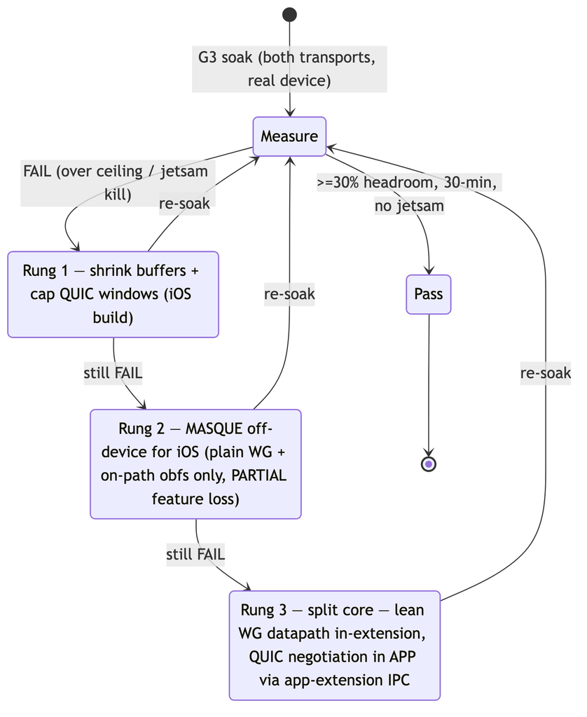

- **Rung 1** (preferred): cap QUIC flow-control windows (M2) + shrink buffer pools (M1) in the iOS build profile; re-soak. Prefer this if it reaches ≥ 30 % headroom [03-client D-CLIENT-1].
- **Rung 2**: move MASQUE off-device for iOS — ship only `plain-udp` + on-path/lwo obfs in-extension; the heavier QUIC carrier is not used on iOS. **Partial feature loss** (no MASQUE on the most censorship-hostile networks for iOS) — an explicit product decision.
- **Rung 3**: split the core — only the lean WG datapath runs in the extension; QUIC CONNECT-UDP negotiation runs in the *app* process and the established carrier is handed to the extension via app-extension IPC. Highest complexity; last resort.

### 6.5 macOS does NOT share this constraint

macOS `NEPacketTunnelProvider` (delivered as a System Extension or app-extension) runs with **desktop-class memory** — there is **no 15/50 MiB jetsam cap** equivalent [research-ios_android §3.5 contrast (Android), §8 here]. The full `masque-h3` carrier and generous buffers are fine on macOS. **Only iOS is the binding memory constraint**; the same Rust core links into both, but the **iOS build profile** (M1–M5, §6.2) is the lean one (§7, §8).

## 7. Swift⇄Rust staticlib build (`aarch64-apple-ios`)

The core is built as a size-first static archive and linked into the extension [research-ios_android §2]. Smaller code = fewer mapped pages = lower NE footprint *and* smaller app.

### 7.1 Crate type & Cargo profile

```
# helix-ffi/Cargo.toml
[lib]
crate-type = ["staticlib"]          # .a linked into the .appex (no dylib entitlement friction)

# Cargo.toml — size-first release profile (research-ios_android §2)
[profile.release]
opt-level     = "z"                 # smallest code (benchmark "s" too — often faster, ~same size)
lto           = "fat"               # whole-program; max size reduction
codegen-units = 1                   # better cross-module size opt (slower compile)
panic         = "abort"             # drops unwinding tables + FFI-soundness (F3) — REQUIRED
strip         = true                # strip symbols (~3–8% extra)
```

### 7.2 iOS target build (size-first), with the nightly `build-std` win

```bash
# Stable, baseline:
cargo build --release --target aarch64-apple-ios -p helix-ffi

# Largest reduction (nightly build-std — drops std unwinding/format machinery, incl. gimli):
cargo +nightly build --release --target aarch64-apple-ios -p helix-ffi \
  -Z build-std=std,panic_abort \
  -Z build-std-features=panic_immediate_abort,optimize_for_size
# Representative reported reduction ~43% (build-std + panic_immediate_abort + optimize_for_size)
# [research-ios_android §2].
```

| Flag | Effect | Source |
| --- | --- | --- |
| `opt-level="z"`/`"s"` | smallest code; benchmark both | [research-ios_android §2] |
| `lto="fat"` | whole-program inlining/dead-strip | [research-ios_android §2] |
| `codegen-units=1` | cross-module size opt | [research-ios_android §2] |
| `panic="abort"` | drops unwind tables; FFI-sound (F3) | [research-ios_android §2] |
| `strip=true` | removes names/debug (~3–8%) | [research-ios_android §2] |
| `build-std` + `panic_immediate_abort` + `optimize_for_size` | drops gimli/format from std (~43%) | [research-ios_android §2] |
| dependency audit | avoid fat deps (regex/format/heavy async) that bloat code | bitdrift [research-ios_android §2] |
| prefer `dyn` over generic explosion on cold paths | curb monomorphization bloat | bitdrift [research-ios_android §2] |

### 7.3 Linking into the extension & binding generation

- The `.a` is linked into the `HelixTunnel.appex` target; the linker dead-strips unreferenced symbols [research-ios_android §2.4]. A universal/xcframework packaging is `UNVERIFIED` per device-arch matrix — Phase-0/1 ships `aarch64-apple-ios` device + `aarch64-apple-ios-sim`
  - `aarch64/x86_64-apple-darwin` for macOS, assembled into an `xcframework`.
- **Bindings (D-CLIENT-3):** UniFFI generates the typed Swift wrapper (`HelixClientConfig`, enums) from the `helix-ffi` UDL/proc-macro; the raw callback pump (§4.2/§4.3) uses the cbindgen C header where UniFFI's callback ergonomics are thin [03-client D-CLIENT-3, research-flutter_ffi]. Both read **one** Rust surface; a header/UDL drift FAILs CI (F5).
- The Dart side links the **same** core via `flutter_rust_bridge` for the in-app logic-only calls (`exits`/`setExit`/`setShields`) that do not touch the OS tunnel [03-client §3.2] — but those run in the **app** process, distinct from the extension's linked copy. The two linked copies share source, never runtime state (the extension's core owns the tunnel; the app's frb core is logic-only). `UNVERIFIED`: whether Phase-1 links the frb core in the app at all on iOS, or routes all logic calls through `sendProviderMessage` to the single in-extension core — a Phase-0 G5 decision (recommend the latter to keep ONE live core).

## 8. macOS desktop-class differences

| Aspect | iOS | macOS |
| --- | --- | --- |
| Memory | hard jetsam ceiling (~50 MiB doc / ~12–15 MB budget, §6) | **desktop-class, no NE jetsam cap** [research-ios_android §3.5 contrast] — full `masque-h3` + generous buffers |
| Extension packaging | app-extension (`.appex`) bundled in the app | **System Extension** (`.systemextension`, `NEMachServiceName`) OR app-extension; sysext needs `OSSystemExtensionRequest` activation + user approval in System Settings |
| Per-app split tunnel | not available to 3rd-party apps | `excludeLocalNetworks` + app-aware routing possible; still no arbitrary per-app like Android |
| Build profile | the lean §6.2 M1–M5 profile | may relax buffer caps (M1/M2) for throughput; same source, different feature flags |
| Signing | Apple notarize (App Store / TestFlight) | Apple notarize + **System Extension entitlement** (`com.apple.developer.networking.networkextension` = `packet-tunnel-provider`, sysext gatekeeper) [03-client §11] |

The Swift `PacketTunnelProvider` source is **shared** between iOS and macOS targets (one `PacketTunnelProvider.swift`); the build flavors differ only in (a) extension packaging, (b) the Rust core build profile, and (c) entitlements/signing. The Dart `TunnelPlatform` impl is shared too (`AppleTunnelPlatform` with a thin `Platform.isMacOS` branch only for the sysext activation request) [03-client §5 payoff].

## 9. Lifecycle state machines

### 9.1 Extension-process tunnel lifecycle (NE provider)

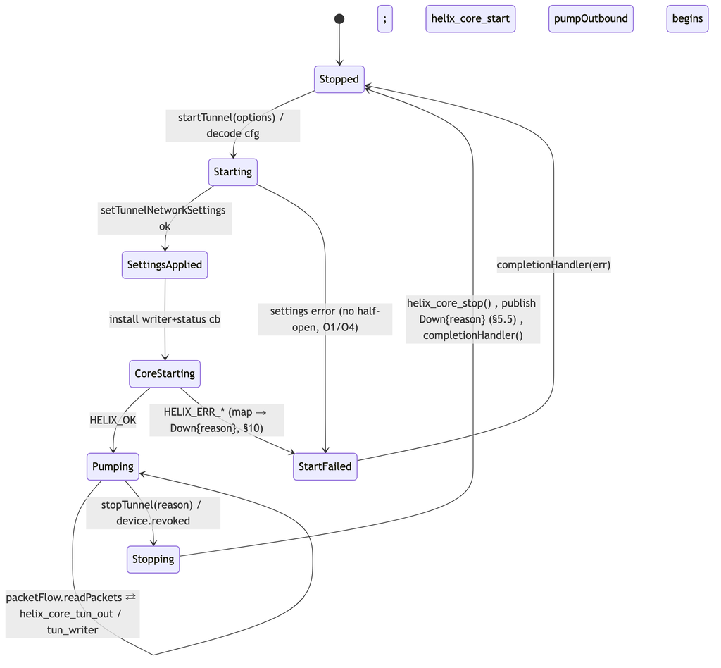

### 9.2 App-side connect controller (drives the extension)

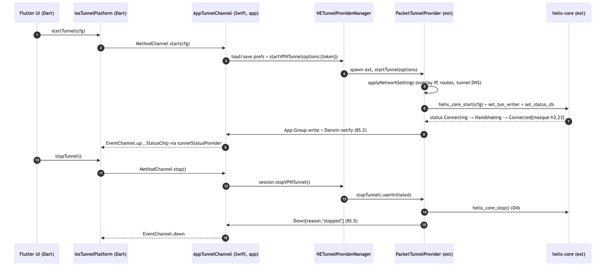

## 10. Error handling & edge cases

| # | Edge case | Handling | Constitution / source |
| --- | --- | --- | --- |
| E1 | VPN permission sheet declined | `saveToPreferences` returns `NEVPNError` → `permissionDenied` (not `error`); no enabled config left behind (O1) | §11.4.6, [03-client §4 O1] |
| E2 | `setTunnelNetworkSettings` fails | `started=false`, `completionHandler(err)`; never enter Pumping with no settings (no half-open) | [03-client §4 O1/O4] |
| E3 | `helix_core_start` → `HELIX_ERR_AUTH` (revoked key) | terminal **without retry**; `Down{reason:"auth-failed"}` → `revoked`; ladder escalation pointless (would mask revocation) | [01-ORCH §5.4] |
| E4 | `HELIX_ERR_HANDSHAKE` (carrier up, WG silent) | core escalates the ladder internally; status shows `Reconnecting`; not a provider failure | [01-ORCH §7], [01-TT §6] |
| E5 | iOS jetsam kills the extension (OOM) | NE restarts the provider; on-demand rules + `includeAllNetworks` keep traffic blocked during the gap (no leak); §6 budget is the prevention | [research-ios_android §1], §6 |
| E6 | Device sleep / network change (Wi-Fi→cellular) | `wake()` no-op; **WG roams** onto the new path on the next handshake/keepalive — no re-dial needed; the core's roam fast-path applies | [01-ORCH §7.5] |
| E7 | Per-app split tunnel requested on iOS | NOT available to 3rd-party apps on iOS; `splitExcludeApps` is surfaced as unsupported (honest, not silently dropped) | §11.4.6, [03-client §4] |
| E8 | App killed/backgrounded while connected | the extension keeps running (separate process); on app relaunch the §5.3 pull resyncs status — UI never lies (CI2) | §1, §5.3 |
| E9 | Darwin notification missed (delivery is best-effort) | the §5.4 `NEVPNStatus` backstop + the §5.3 cold-start pull recover the latest status | §5.3/§5.4 |
| E10 | `Oversize` datagram from the core | the core lowers inner MTU / fragments; the shim never truncates a packet (I2) | [01-TT §4.8], [01-ORCH §6.6] |
| E11 | Rust panic across the C ABI | `panic=abort` → clean process abort (NE restarts), never UB across FFI (F3) | §4.4 F3, §7 |
| E12 | Session token leak risk | token rides in `startVPNTunnel(options:)` (never in saved prefs plist), copied to `SecretBytes`, zeroized, never logged (F4) | §11.4.10, §4.4 F4 |
| E13 | macOS System Extension not yet approved | `OSSystemExtensionRequest` pends; surface a "approve in System Settings" prompt; do not claim connected | §11.4.6, §8 |

## 11. Memory / size / performance budgets

[output not shown]

All budgets are **captured evidence** (Instruments RSS report + throughput CSV + window-scoped MP4 per §11.4.159), measured on a real device, never asserted (§11.4.6/.123).

## 12. Test points — tied to the §11.4.169 test-type vocabulary

Every Apple-shim workable item declares its required test types from the §11.4.169 closed set; the only permitted absence of a warranted type is an honest §11.4.3 SKIP-with-reason, never a silent gap. Four-layer enforcement per §11.4.4(b) applies to every closure. Codes match the sibling data-plane spec [01-TT §9].

| Code | Type | Concrete Apple-shim test point | Evidence (§11.4.5/.69/.107) |
| --- | --- | --- | --- |
| `UT` | unit | `decodeTunnelConfig`/`downReasonFor`/`_decodeEvent` mapping tables; `TunnelStatus` CBOR round-trip identity; FFI header drift check (F5) | `xcodebuild test` + `cargo test` logs; drift diff |
| `IT` | integration | app↔︎extension `sendProviderMessage` round-trip returns current status; App-Group write + Darwin notify → app observer fires; core staticlib links + starts in a host-extension harness | provider-message capture; notify-observed log |
| `E2E` | end-to-end | real-device: tap Connect → overlay IP assigned → `curl http://<LAN host>/` over `plain-udp` **and** `masque-h3`; tap Disconnect → traffic blocked (kill-switch) | window-scoped MP4 of the journey (§11.4.159) + OCR `StatusChip "masque-h3 · 23ms"` |
| `FA` | full-automation (§11.4.25/.52/.98, deterministic §11.4.50) | scripted XCUITest drives connect→status→disconnect **N=3 identical** runs producing the same ordered `PlatformTunnelEvent` trace | 3× identical event-trace artifacts |
| `CH` | Challenges (challenges submodule §11.4.27(B)) | a Challenge scores the captured G3 + E2E evidence (not config) | Challenge `result.json` |
| `HQA` | HelixQA (helix_qa submodule) | autonomous QA session drives connect/roam/revoke across iOS + macOS targets | HelixQA session evidence |
| `LOAD` | DDoS / load-flood | sustained 1 GB transfer + handshake churn; no fd/buffer leak in the extension | throughput CSV + footprint trace |
| `SEC` | security (§11.4.10 + security submodule) | (a) session token appears in **no** log / no saved prefs plist (plant-and-grep); (b) `tshark` shows `masque-h3` flow = HTTP/3 with **no WG signature** (G2); (c) no plaintext packet logged by the shim | grep-empty proof; `tshark` classification |
| `SC` | stress + chaos (§11.4.85) | iface flap (Wi-Fi→cellular) → reconnect < 3 s (roam); kill the extension mid-transfer → NE restart, **no leak** during gap (E5); device sleep/wake | recovery trace; no-leak capture |
| `CONC` | concurrency / atomicity | concurrent outbound pump + inbound writer under load; status push during a transport swap drops zero packets | concurrency harness log |
| `RACE` | race / deadlock | `cargo test --features loom` on the in-crate status/writer atomics; TSan on the Swift bridge | loom + TSan report |
| `MEM` | memory (**G3 make-or-break**) | extension `phys_footprint` under ceiling with ≥ 30 % headroom, 30-min soak, **both** transports, real device + upload-heavy spike scenario | Instruments RSS report (§6.3) |
| `BENCH` | benchmarking / performance | per-transport through-tunnel throughput / CPU on device; status-bridge latency; staticlib size delta per build flag | throughput/CPU/size CSV |

### 12.1 Apple-specific acceptance gates

- **G3 (iOS NE memory) — make-or-break** [04_P0 §6.4]: §6.3 soak passes for both transports with ≥ 30 % headroom; if it fails, the §6.4 fallback ladder is engaged and the chosen rung is surfaced to the operator (§11.4.66) — never a silent feature drop.
- **G5 (FFI drives the core)** [04_P0 §9]: the extension's `helix_core_start` + pump + status callback drive a `Connecting → Handshaking → Connected{masque-h3,23}` transition observed by the Dart UI via the §5 bridge — recorded.
- **No-leak gate** (SEC + SC): with `includeAllNetworks`, no egress escapes during the extension-restart window; proven by capture, not assumed (§11.4.6).

### 12.2 Anti-bluff rule for this shim (§11.4.5/.69/.107)

The shim is the **only untyped seam** (Swift⇄Rust⇄Dart, cross-process) [03-client §4 O5] and is covered on **real devices**, never by a mock-claiming-PASS (§11.4.27). A green Swift unit test does NOT prove the user is protected — the authoritative evidence is the on-device E2E window-scoped MP4 with the `StatusChip` reading `masque-h3 · direct · 23ms` confirmed by OCR/vision validation (§11.4.158/.159), plus the Instruments G3 RSS report.

## 13. Cross-doc seams & surfaced decisions

| Seam | Fixed value | Owned by / consumed from |
| --- | --- | --- |
| **FFI surface** (`helix_core_start/stop/apply_map`, `tun_out`, `set_tun_writer`, `set_status_cb`, `current_status`) | §4 (cbindgen C ABI) | binds [03-client §3] (the surface contract); the core internals are [01-TT]/[01-ORCH] |
| **Core-emitted `TunnelStatus`** (5-variant, byte-consistent) | §5.1 = [01-ORCH §4.1] | the Dart UI projection extension is [03-client §3.1]; this doc keeps the wire enum consistent |
| **`TunnelPlatform` channel** (`startTunnel/stopTunnel/events`, `PlatformTunnelEvent`) | §2 | [03-client §4]; `device.revoked` → `revoked` from doc 02 |
| **Packet-pump-not-fd** (Apple uses `tun_out`/`tun_writer`; Android/Linux use `attach_tun(fd)`) | §3.3, §4.2 | the only per-OS FFI divergence; [research-ios_android §3] |
| **iOS NE memory ceiling = the Rust-not-Go justification** (G3) | §6 | [04_ARCH §5.6], the whole "Rust core" thesis; build flags §7 |

### 13.1 Surfaced decisions (per §11.4.66 — options + recommendation, never silently resolved)

| # | Decision | Option A | Option B | Recommendation |
| --- | --- | --- | --- | --- |
| **D-CLIENT-1** | iOS NE memory fallback if G3 fails | shrink buffers / cap QUIC windows in iOS build (rung 1) | move MASQUE off-device (rung 2) **or** split-core app-extension IPC (rung 3) | **Gate on the G3 measurement** (§6.3). Prefer A if it reaches ≥ 30 % headroom; B only if A insufficient. Each is a real product decision — surface to operator [04_P0 §6.4]. |
| **D-CLIENT-3** | Native binding generator | **UniFFI** (typed Swift) + cbindgen for the raw pump | cbindgen C header everywhere | **UniFFI for typed types, cbindgen for the callback pump** (§4) [03-client D-CLIENT-3]. |
| **D-APPLE-1** | iOS logic-only calls (`exits`/`setExit`) location | frb core linked in the **app** (second linked copy, logic-only) | route all logic via `sendProviderMessage` to the **single** in-extension core | **B (single live core)** to avoid two cores' state divergence; confirm at Phase-0 G5. `UNVERIFIED` until measured. |
| **D-APPLE-2** | Status push mechanism (ext→app) | App-Group file + Darwin notify (push) + `sendProviderMessage` (pull backstop) | poll `sendProviderMessage` on a timer only | **A** — push is sub-second + battery-friendly; the pull is the cold-start/missed-notify backstop (§5.2/§5.3). |

## Sources verified

- `final/03-client-core-and-ui.md` `[03-client]` — §0.1 (client invariants CI1–CI6), §3 (FFI surface + `TunnelStatus`/`Shields`/`ExitOption`), §4 (`TunnelPlatform` contract + obligations O1–O5), §5.1 (iOS/macOS NE shim skeleton + memory gate + fallbacks), §10 (budgets), §11 (signing/CI), §12 (testing), §14 (D-CLIENT-1/2/3).
- `final/v02-data-plane/orchestrator-and-state.md` `[01-ORCH]` — §4.1 (the 5-variant `TunnelStatus` enum — the consistency anchor), §4.4 (`Down.reason` prefixes), §5.4 (auth-failed terminal-no-retry), §6.4 (revocation), §6.6 (MTU coupling), §7.5 (roam fast-path), §8 (kill-switch + DNS coupling).
- `final/v02-data-plane/transport-trait.md` `[01-TT]` — §1 (invariants I1/I2), §2.3 (`TransportHealth`), §3.2 (`SecretBytes` redaction/zeroize), §4.8 (effective_mtu per carrier), §6 (ladder), §9 (the §11.4.169 test-type vocabulary).
- `v09-research/research-ios_android.md` `[research-ios_android]` — §1 (NE 50 MiB documented / 15 MB historical / 15 MB observed kills / do-not-hardcode / measure on device / whole-process scope / spike-driven jetsam), §2 (staticlib opt-level=z+fat-LTO+codegen-units=1+panic=abort+ strip + build-std/optimize_for_size ~43%), §3 (Android fd contrast: detachFd/protect — Apple has no userspace fd), §4 (cross-platform synthesis: iOS is the binding constraint, ~12–15 MB budget). All sources accessed 2026-06-25.
- `04_VPN_CLD/HelixVPN-Phase0-Spike.md` `[04_P0]` — §6 (iOS NE memory experiment G3 + fallbacks), §9 (FFI boundary G5). `04_VPN_CLD/HelixVPN-Architecture-Refined.md` `[04_ARCH]` — §5.6 (iOS NE ceiling = Rust-not-Go), §5.1–§5.7 (shim matrix). `04_VPN_CLD/HelixVPN-helix-ui- Flutter.md` `[04_UI]` — §5/§6 (FFI surface, per-platform shim). `[SYN]` — §5 (client architecture), §3 (D4 overlay addressing).

*Constitution: §11.4.44 (revision header), §11.4.6/§11.4.66 (decisions = options + recommendation; UNVERIFIED never fabricated), §11.4.10 (no secret leak — session token never persisted/logged), §11.4.5/§11.4.69/§11.4.107/§11.4.158/§11.4.159 (captured/window-scoped evidence; G3 RSS + on-device MP4), §11.4.169 (test-type coverage), §11.4.133 (signed privileged code / target safety).*

*End of nano-detail specification — Apple shim (iOS/macOS NEPacketTunnelProvider), Volume 4 (Clients). Pairs with [03-client §5.1] (the overview this deepens), [01-ORCH §4] (the `TunnelStatus` enum it mirrors), and [01-TT] (the carrier the core drives). Surfaced decisions: D-CLIENT-1 (iOS memory fallback), D-CLIENT-3 (binding generator), D-APPLE-1 (single-core vs dual), D-APPLE-2 (status push mechanism) — all presented, none silently resolved (§11.4.66).*